# A Break Down of Password Dumps and Data Breaches from 2004 to 2021

2022-11-14

One of the hallmarks of a good cybersecurity system is that no one besides the user should ever know their password or PII (Personally Identifiable Information), and no one includes the system. When good services store passwords, they will perform a hashing algorithm and store the result rather than the password itself. This hashing algorithm works like a complicated random number generator that takes the password as it’s starting information, does a bunch of intentionally convoluted functions, then spits out a giant string of numbers, letters and symbols based on the results. This is done so that if there is a data breach that leads to the organization’s user data being exposed, the attacker is hopefully left with nothing but useless data.

Now, these hashing algorithms are very hard to develop, because computers are actually really bad at being random. They only do what you tell them to and that makes every hash they could give you potentially reversible if you can figure out the equation that made it based on the starting values. There are things you can do to counteract this however. In addition to extremely complicated processes, you can also add in values taken from sources besides the entered information, referred to as SALT. This can include things like the time, the number of times the algorithm has been used in the past hour, how many days till the next full moon, as long as the number would be hard to predict and recreate then it’ll make for good salt. All of these techniques and requirements for a strong algorithm means that they are expensive to make and maintain, which means there are only a handful of commonly used ones that meet the sort of high security requirements many organizations require. Which means there is a lot of money to be made in breaking them, finding out how to reverse them, and rendering a major security feature ineffective.

If you want to be a boxer, you have to spar. You can spend as many hours as you want hitting a speed bag, jumping rope, working on your footwork or lifting weights as you like, but unless you have experience in a ring, you’ll never be ready for an actual fight. Cybersecurity is the sameYou can spend countless dollars and hours, spend all your time researching the most complex mathematical theorems for cryptography and rack your brain finding obscure places to grab salt variables from, but none of that will matter if it can’t survive a real cracking attack.

The way you test that is with password dumps. Password dumps are large banks of plaintext passwords taken from past data breaches. When a data breach occurs to an encrypted bank of passwords, attackers will take the passwords that have been encrypted with a hashing algorithm and password dumps of other organizations where the passwords are in plain text. They then run the plain text passwords through the algorithm used on the encrypted passwords (or through several if they don’t know what algorithm is in use) and look for matches. The logic here is that if these passwords are being used in other places, it is statistically likely that one of the users in this new dump will have the same. Over time, once enough matches have been found for one algorithm, it’s possible to begin breaking the algorithm itself by reverse engineering what is going on inside of it. So if you want to make sure your algorithm is secure, you have to run these password dump matching attempts (referred to as dictionary attacks) against your own algorithm and plug the gaps yourself before someone else finds them.

In 2009, one of the biggest data breaches of plain text passwords, the kind used in these tests, happened to a site called rockyou.com. Rockyou.com was a social media adjacent site - mostly full of little games and photo editing apps that you could connect back to your main social media sites. In order to connect, rockyou.com would store both the login info for a users rockyou.com account and for their other social media sites on their own servers. This meant that when they got breached, anyone who used their site had their rockyou.com login and their other social media logins leaked in plain text. This lead to a 32.3 million user records being leaked in an infamous password dump called rockyou.txt.

This report will go over the content of rockyou.txt and compare it to other, more modern password dumps in order to show how passwords have changed since 2009. It will also discuss data breaches, their frequency, and who they happen to in order to also discuss where these dumps come from and what people need to be most watchful of if they want to maintain their own personal security.

### Part 0: The Data

Packages are mostly standard, I have left comments next to the non standard ones to show their purpose.

```r
knitr::opts_chunk$set(echo = TRUE)
library(tidyverse)
```

```r
library(stringr) #operations for passwords
library(ggplot2)
library(dplyr)
library(knitr)
library(base) #arrived and wont leave quietly
library(grid) #facet shape and size
library(gtable)
library(scales)#for removing SciNot from graphs
library(treemapify) # for Tree maps
library(ggrepel) # for text wizard stuff
```

Data cleaning is simple to explain and far more of a problem then I could have ever predicted.

cleaning and splitting rockyou, commented out. Source: https://archive.org/details/rockyou.txt

```r
#rockyou <- read.table(file = "rockyou.txt", sep = "\n")
#rockyou <- data.frame(rockyou)
#rockyou <- data.frame(rockyou[!c((nchar(rockyou$V1 , allowNA = TRUE) >= 25)),])
#rockyou <- separate(rockyou, rockyou..c..nchar.rockyou.V1..allowNA...TRUE.....25....., c("0","1","2","3","4","5","6","7","8","9","10","11","12","13","14","15", "16", "17", "18", "19", "20", "21", "22", "23", "24"), sep = "")
#rockyou <- rockyou[c("1","2","3","4","5","6","7","8","9","10","11","12","13","14","15", "16", "17", "18", "19", "20", "21", "22", "23", "24")]
#write.csv(rockyou, "rockyouClean.csv", row.names = FALSE)
```

rock you 2021 file clean and split, commented out Source: https://crackstation.net/crackstation-wordlist-password-cracking-dictionary.htm

```r
#rockyou2021 <- read.table(file = "realhuman_phill.txt", sep = "\n")
#rockyou2021 <- data.frame(rockyou2021)
#rockyou2021 <- data.frame(rockyou2021[!c((nchar(rockyou2021$V1 , allowNA = TRUE) >= 25)),])
#rockyou2021 <- data.frame((separate(rockyou2021, rockyou2021..c..nchar.rockyou2021.V1..allowNA...TRUE.....25...., c("0","1","2","3","4","5","6","7","8","9","10","11","12","13","14","15", "16", "17", "18", "19", "20", "21", "22", "23", "24"), sep = "")))
#rockyou2021 <- rockyou2021[c("X1","X2","X3","X4","X5","X6","X7","X8","X9","X10","X11","X12","X13","X14","X15", "X16", "X17", "X18", "X19", "X20", "X21", "X22", "X23", "X24")]
#write.csv(rockyou2021, "rockyou21Clean.csv", row.names = FALSE)
```

This code is left over from working on the graphs. These functions existed to assist with speed while testing. The size of the data caused long stretches of downtime while testing, so smaller datasets led to faster testing. commented out.

```r
#rockyouTEST <- rockyouTEST %>%  filter(!row_number() %in% c(115128,133338))
#rockyouTEST <- data.frame(rockyouTEST[!c((nchar(rockyouTEST$V1 , allowNA = TRUE) >= 24)),])
#rockyouTEST <- separate(rockyouTEST, rockyouTEST..c..nchar.rockyouTEST.V1..allowNA...TRUE.....24..., c("0","1","2","3","4","5","6","7","8","9","10","11","12","13","14","15", "16", "17", "18", "19", "20", "21", "22", "23", "24"), sep = "")
#rockyouTEST <- head(rockyou,10000)
#rockyouTEST21 <- head(rockyou2021,10000)
```

File Read in

```r
rockyou <- read.csv("rockyouClean.csv")
rockyou2021 <- read.csv("rockyou21Clean.csv")
glimpse(rockyou)
```

```
## Rows: 4,809,580
## Columns: 24
## $ X1  <chr> "1", "1", "1", "p", "i", "p", "1", "r", "1", "a", "n", "d", "b", "…
## $ X2  <chr> "2", "2", "2", "a", "l", "r", "2", "o", "2", "b", "i", "a", "a", "…
## $ X3  <chr> "3", "3", "3", "s", "o", "i", "3", "c", "3", "c", "c", "n", "b", "…
## $ X4  <chr> "4", "4", "4", "s", "v", "n", "4", "k", "4", "1", "o", "i", "y", "…
## $ X5  <chr> "5", "5", "5", "w", "e", "c", "5", "y", "5", "2", "l", "e", "g", "…
## $ X6  <chr> "6", NA, "6", "o", "y", "e", "6", "o", "6", "3", "e", "l", "i", "y…
## $ X7  <chr> NA, NA, "7", "r", "o", "s", "7", "u", "7", NA, NA, NA, "r", NA, NA…
## $ X8  <chr> NA, NA, "8", "d", "u", "s", NA, NA, "8", NA, NA, NA, "l", NA, NA, …
## $ X9  <chr> NA, NA, "9", NA, NA, NA, NA, NA, NA, NA, NA, NA, NA, NA, NA, NA, N…
## $ X10 <chr> NA, NA, NA, NA, NA, NA, NA, NA, NA, NA, NA, NA, NA, NA, NA, NA, NA…
## $ X11 <chr> NA, NA, NA, NA, NA, NA, NA, NA, NA, NA, NA, NA, NA, NA, NA, NA, NA…
## $ X12 <chr> NA, NA, NA, NA, NA, NA, NA, NA, NA, NA, NA, NA, NA, NA, NA, NA, NA…
## $ X13 <chr> NA, NA, NA, NA, NA, NA, NA, NA, NA, NA, NA, NA, NA, NA, NA, NA, NA…
## $ X14 <chr> NA, NA, NA, NA, NA, NA, NA, NA, NA, NA, NA, NA, NA, NA, NA, NA, NA…
## $ X15 <chr> NA, NA, NA, NA, NA, NA, NA, NA, NA, NA, NA, NA, NA, NA, NA, NA, NA…
## $ X16 <chr> NA, NA, NA, NA, NA, NA, NA, NA, NA, NA, NA, NA, NA, NA, NA, NA, NA…
## $ X17 <chr> NA, NA, NA, NA, NA, NA, NA, NA, NA, NA, NA, NA, NA, NA, NA, NA, NA…
## $ X18 <chr> NA, NA, NA, NA, NA, NA, NA, NA, NA, NA, NA, NA, NA, NA, NA, NA, NA…
## $ X19 <chr> NA, NA, NA, NA, NA, NA, NA, NA, NA, NA, NA, NA, NA, NA, NA, NA, NA…
## $ X20 <chr> NA, NA, NA, NA, NA, NA, NA, NA, NA, NA, NA, NA, NA, NA, NA, NA, NA…
## $ X21 <chr> NA, NA, NA, NA, NA, NA, NA, NA, NA, NA, NA, NA, NA, NA, NA, NA, NA…
## $ X22 <chr> NA, NA, NA, NA, NA, NA, NA, NA, NA, NA, NA, NA, NA, NA, NA, NA, NA…
## $ X23 <chr> NA, NA, NA, NA, NA, NA, NA, NA, NA, NA, NA, NA, NA, NA, NA, NA, NA…
## $ X24 <chr> NA, NA, NA, NA, NA, NA, NA, NA, NA, NA, NA, NA, NA, NA, NA, NA, NA…
```

```r
glimpse(rockyou2021)
```

```
## Rows: 6,704,326
## Columns: 24
## $ X1  <chr> "\004", "\004", "\004", "\b", "\b", "\b", "\b", "\b", "!", "!", "!…
## $ X2  <chr> "*", "*", "*", NA, "A", "a", "I", "i", NA, " ", " ", " ", " ", " "…
## $ X3  <chr> "\003", "\003", "\003", NA, "6", "6", "E", "e", NA, " ", "-", "3",…
## $ X4  <chr> "7", "7", "7", NA, "_", "_", "1", "1", NA, " ", NA, NA, NA, NA, NA…
## $ X5  <chr> "¡VAMOS!\003", "¡Vamos!\003", "¡vamos!\003", NA, "1", "1", "6", "6…
## $ X6  <chr> NA, NA, NA, NA, "2", "2", "8", "8", NA, NA, NA, NA, NA, NA, NA, NA…
## $ X7  <chr> NA, NA, NA, NA, "3", "3", NA, NA, NA, NA, NA, NA, NA, NA, NA, NA, …
## $ X8  <chr> NA, NA, NA, NA, NA, NA, NA, NA, NA, NA, NA, NA, NA, NA, NA, NA, NA…
## $ X9  <chr> NA, NA, NA, NA, NA, NA, NA, NA, NA, NA, NA, NA, NA, NA, NA, NA, NA…
## $ X10 <chr> NA, NA, NA, NA, NA, NA, NA, NA, NA, NA, NA, NA, NA, NA, NA, NA, NA…
## $ X11 <chr> NA, NA, NA, NA, NA, NA, NA, NA, NA, NA, NA, NA, NA, NA, NA, NA, NA…
## $ X12 <chr> NA, NA, NA, NA, NA, NA, NA, NA, NA, NA, NA, NA, NA, NA, NA, NA, NA…
## $ X13 <chr> NA, NA, NA, NA, NA, NA, NA, NA, NA, NA, NA, NA, NA, NA, NA, NA, NA…
## $ X14 <chr> NA, NA, NA, NA, NA, NA, NA, NA, NA, NA, NA, NA, NA, NA, NA, NA, NA…
## $ X15 <chr> NA, NA, NA, NA, NA, NA, NA, NA, NA, NA, NA, NA, NA, NA, NA, NA, NA…
## $ X16 <chr> NA, NA, NA, NA, NA, NA, NA, NA, NA, NA, NA, NA, NA, NA, NA, NA, NA…
## $ X17 <chr> NA, NA, NA, NA, NA, NA, NA, NA, NA, NA, NA, NA, NA, NA, NA, NA, NA…
## $ X18 <chr> NA, NA, NA, NA, NA, NA, NA, NA, NA, NA, NA, NA, NA, NA, NA, NA, NA…
## $ X19 <chr> NA, NA, NA, NA, NA, NA, NA, NA, NA, NA, NA, NA, NA, NA, NA, NA, NA…
## $ X20 <chr> NA, NA, NA, NA, NA, NA, NA, NA, NA, NA, NA, NA, NA, NA, NA, NA, NA…
## $ X21 <chr> NA, NA, NA, NA, NA, NA, NA, NA, NA, NA, NA, NA, NA, NA, NA, NA, NA…
## $ X22 <chr> NA, NA, NA, NA, NA, NA, NA, NA, NA, NA, NA, NA, NA, NA, NA, NA, NA…
## $ X23 <chr> NA, NA, NA, NA, NA, NA, NA, NA, NA, NA, NA, NA, NA, NA, NA, NA, NA…
## $ X24 <chr> NA, NA, NA, NA, NA, NA, NA, NA, NA, NA, NA, NA, NA, NA, NA, NA, NA…
```

### Part 1: rockyou.txt

How long is the average password? The first graph was a very simply process, created a column that was a sum of all non na values for each row and then graphed onto a histogram. I also added in a mean line for easier comparison later.

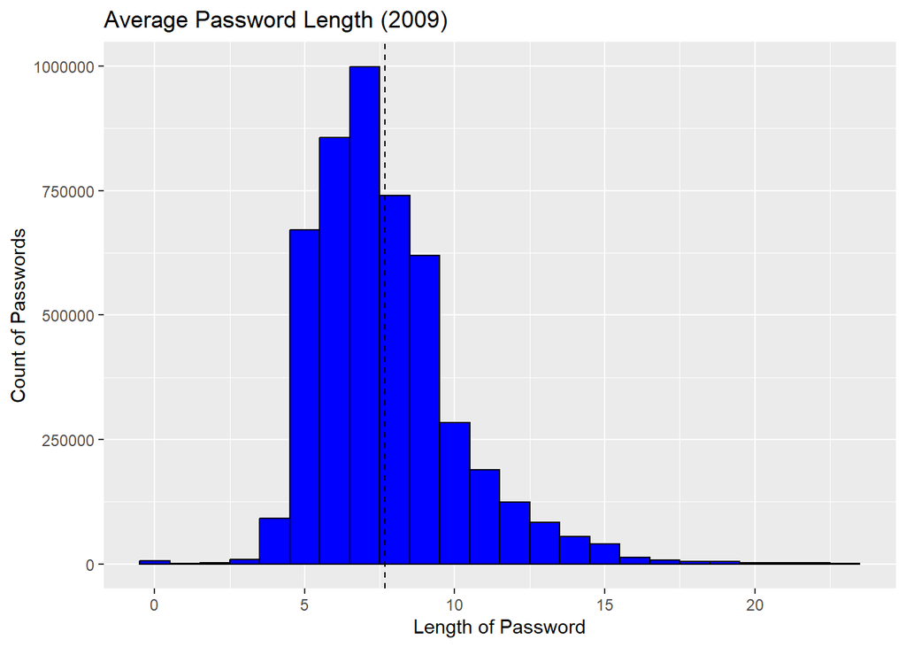

```r
lengthCompare <- rockyou
lengthCompare$count <- rowSums(!is.na(lengthCompare[-1]))
lengthCompare %>% ggplot(aes(count)) + geom_histogram(bins = 24, color = "black", fill = "blue") + geom_vline(aes(xintercept = mean(count)), color = "black", linetype = "dashed") + ggtitle("Average Password Length (2009)") + ylab("Count of Passwords") + xlab("Length of Password")
```

What is the most common character used in each position of the password? For this graph, the function finds the most common value for each column, assigns it to a variable as a named int. All of those named ints go into a vector, and then use the enframe command to make a dataframe with the letters and the values separated into columns. I then pushed a column full of the “position” to identify it.

```r
commonDF <- rockyou

X1 <- sort(table(commonDF$X1),decreasing=TRUE)[1]
X2 <- sort(table(commonDF$X2),decreasing=TRUE)[1]
X3 <- sort(table(commonDF$X3),decreasing=TRUE)[1]
X4 <- sort(table(commonDF$X4),decreasing=TRUE)[1]
X5 <- sort(table(commonDF$X5),decreasing=TRUE)[1]
X6 <- sort(table(commonDF$X6),decreasing=TRUE)[1]
X7 <- sort(table(commonDF$X7),decreasing=TRUE)[1]
X8 <- sort(table(commonDF$X8),decreasing=TRUE)[1]
X9 <- sort(table(commonDF$X9),decreasing=TRUE)[1]
X10 <- sort(table(commonDF$X10),decreasing=TRUE)[1]
X11 <- sort(table(commonDF$X11),decreasing=TRUE)[1]
X12 <- sort(table(commonDF$X12),decreasing=TRUE)[1]
X13 <- sort(table(commonDF$X13),decreasing=TRUE)[1]
X14 <- sort(table(commonDF$X14),decreasing=TRUE)[1]
X15 <- sort(table(commonDF$X15),decreasing=TRUE)[1]
X16 <- sort(table(commonDF$X16),decreasing=TRUE)[1]
X17 <- sort(table(commonDF$X17),decreasing=TRUE)[1]
X18 <- sort(table(commonDF$X18),decreasing=TRUE)[1]
X19 <- sort(table(commonDF$X19),decreasing=TRUE)[1]
X20 <- sort(table(commonDF$X20),decreasing=TRUE)[1]
X21 <- sort(table(commonDF$X21),decreasing=TRUE)[1]
X22 <- sort(table(commonDF$X22),decreasing=TRUE)[1]
X23 <- sort(table(commonDF$X23),decreasing=TRUE)[1]
X24 <- sort(table(commonDF$X24),decreasing=TRUE)[1]
most <- c(X1,X2,X3,X4,X5,X6,X7,X8,X9,X10,X11,X12,X13,X14,X15,X16,X17,X18,X19,X20,X21,X22,X23,X24)
#frequencyDF <- data.frame(as.list(most))
frequencyDF <- enframe(most, name = "Character", value = "Frequency")
frequencyDF$Position <- seq(1,24)
```

After that, I graphed it on a bar graph with the most common character at the top.

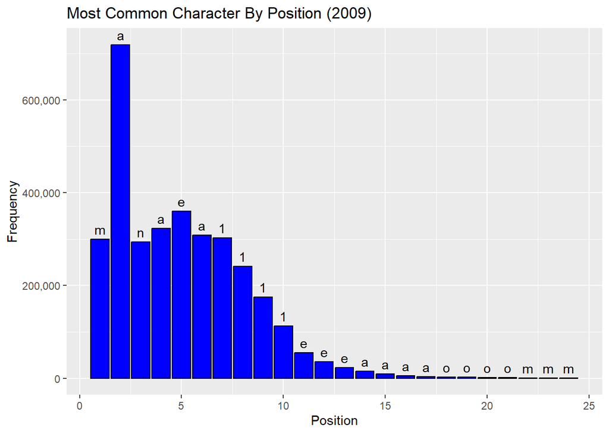

```r
plot5 <- frequencyDF %>%
  ggplot(aes(x = Position, y = Frequency)) + geom_col(label = frequencyDF$Character, color = "black", fill = "blue") + geom_text(aes(label = Character), vjust = -.5) + ggtitle("Most Common Character By Position (2009)")
plot5 + scale_y_continuous(labels = label_comma())
```

While the frequency of lowercase m is shocking, the massive spike of a isn’t when you consider that in every password dump ever, the most common password is always “password” and if it isn’t, then the most common passwords will be “password” with whatever requirements that the system implemented for password complexity, i.e. if the system requires a capital, it’ll be “Password” or if it needs that and a symbol it might be “Password!” or “Password?”. People generally don’t change the a when they do this which is why that one sticks so far out. Outside of that spike, pretty much every other column is a very close race between the winner and every other lower case letter.

What are people using for their passwords? This one hurt and was the biggest time sink. After a lot of different methods were tried that didn’t work, this is what ended up being the best way I could find. I made a function that checks if the input is in a set of vectors called lower, upper and numbers. I didn’t make a symbols vector since that could be almost anything and it was easier to just consider it a symbol if it didn’t fit the other 3 types.

```r
uppers <- LETTERS[1:26]
lowers <- letters[1:26]
numbers <- seq(0,9)

catDecider <- function(x) {
  #check <- x
  if(x %in% lowers){
    return(1)
  }
  else if (x %in% uppers){
    return(2)
  }
  else if (x %in% numbers) {
    return(3)
  }
  return (4)
}
```

So it looks through the entire frame using the for loop, checks what type of symbol it is, then replaces it with the corresponding number. This function takes a very long time to run through the whole function, long enough that it needed to be cut down to 100000 records in order to have it run in less than an hour. After that, I grouped the data by the category and then by character, made a stacked bar graph with the color as the category, the X as the position and the height and fill by the count.

```r
#characterStackcsv <- rockyou[sample(nrow(rockyou), 100000), ]
#write.csv(characterStackcsv, "sample2009.csv", row.names = FALSE)
```

Function to prevent issues with randomness causing unexpected reacionts when knitting, commented out

```r
characterStack <- read.csv("sample2009.csv")
for (j in 1:nrow(characterStack)) {
  for (i in 1:ncol(characterStack)) {
    if (!is.na(characterStack[j,i])) {
      characterStack[j,i] <- catDecider(characterStack[j,i])
    }
  }
}
```

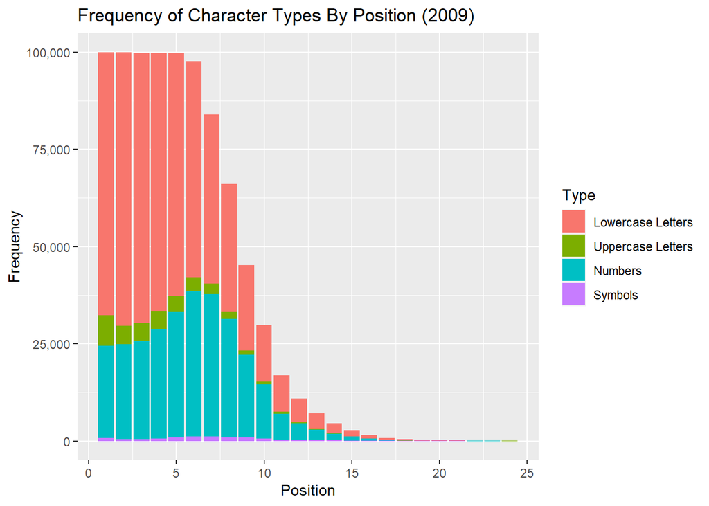

```r
X1 <- table(characterStack$X1)
X2 <- table(characterStack$X2)
X3 <- table(characterStack$X3)
X4 <- table(characterStack$X4)
X5 <- table(characterStack$X5)
X6 <- table(characterStack$X6)
X7 <- table(characterStack$X7)
X8 <- table(characterStack$X8)
X9 <- table(characterStack$X9)
X10 <- table(characterStack$X10)
X11 <- table(characterStack$X11)
X12 <- table(characterStack$X12)
X13 <- table(characterStack$X13)
X14 <- table(characterStack$X14)
X15<- table(characterStack$X15)
X16 <- table(characterStack$X16)
X17 <- table(characterStack$X17)
X18<- table(characterStack$X18)
X19<- table(characterStack$X19)
X20 <- table(characterStack$X20)
X21 <- table(characterStack$X21)
X22 <- table(characterStack$X22)
X23 <- table(characterStack$X23)
X24 <- table(characterStack$X24)

most <- c(X1,X2,X3,X4,X5,X6,X7,X8,X9,X10,X11,X12,X13,X14,X15,X16,X17,X18,X19,X20,X21,X22,X23,X24)
catDF <- enframe(most, name = "Type", value = "Frequency")
catDF$Position <- c(1,1,1,1,2,2,2,2,3,3,3,3,4,4,4,4,5,5,5,5,6,6,6,6,7,7,7,7,8,8,8,8,9,9,9,9,10,10,10,10,11,11,11,11,12,12,12,12,13,13,13,13,14,14,14,14,15,15,15,15,16,16,16,16,17,17,17,17,18,18,18,18,19,19,19,19,20,20,20,20,21,21,21,21,22,22,22,22,23,23,23,23,24,24,24,24)
catDF <- catDF %>% group_by(catDF$Position)
plot6 <- catDF %>% ggplot(aes(x = Position , y = Frequency, fill = Type )) + geom_col() + ggtitle("Frequency of Character Types By Position (2009)")+ scale_fill_discrete(labels=c('Lowercase Letters', 'Uppercase Letters', "Numbers", "Symbols"))

plot6 + scale_y_continuous(labels = label_comma())
```

So the clear favorite here is lower case letter, which tracks with other observations, that whatever is easiest will be the most popular. Coming in at second is numbers, then uppercase and symbols. Interesting things to note, capital letters trend downwards in terms of frequency the further along the password, but numbers and symbols increase, with symbols (despite being hard to see) increasing as the potential “end” of the passwords by a lot.

This is a good visual of what bad passwords look like. They are quick to type and they are really easy to remember. But times have changed since 2009 and security standards have gotten a lot higher as a result of the web being used for more important things. So you would hope we had gotten better, yeah?